# Test Data Sets

## UVic Climate Model

A simple low dimensional problem using data from the University of Victoria climate model. You can read some limited detail in Wilkinson 2010 [here](https://rich-d-wilkinson.github.io/Publications.html). There are two inputs, Q10 and Kv (something to do with respiration in plants), and the simulator has been run 55 times at the inputs in `design`

```r
load('UVic.rda')
head(design)
```

```
  Q10   Kv
1   1 0.10
2   1 0.15
3   1 0.20
4   1 0.25
5   1 0.30
6   1 0.40
```

The outputs are a time series of CO2 values in `sim.co2`, as well as two flux values for the 80s and 90s in `sim.flux`. Each input to the simulator thus produces one time series and two fluxes. In the paper, we emulated both the fluxes, and the time series, by decomposing the multidimensional output with PCA first.

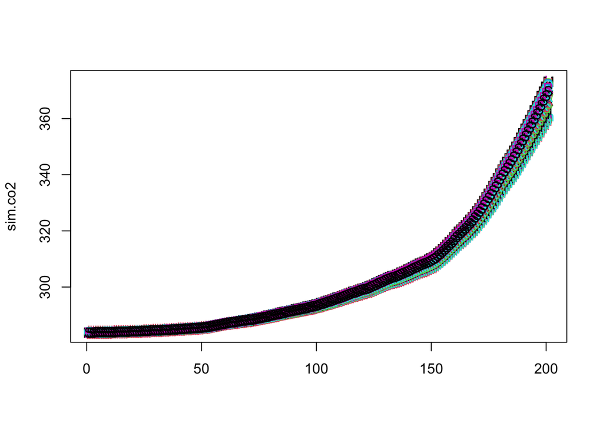

```r
matplot(sim.co2)
```

There are also the Keeling observed physical measurements of CO2 values in `field.co2` and `field.flux`. The aim is learn which input parameters lead to these measurements.

## Climate data

Climate model data from [here](https://www.nature.com/articles/s41558-018-0197-7). I think its from the GENIE model.

```r
library(tidyverse)
dat=read_csv(file='Holden2018.csv')
str(dat)
```

```
spc_tbl_ [906 × 56] (S3: spec_tbl_df/tbl_df/tbl/data.frame)
 $ ID      : num [1:906] 16 17 18 19 20 26 27 28 29 37 ...
 $ OHD     : num [1:906] 0.224 -0.458 -0.318 -0.686 -0.238 ...
 $ OVD     : num [1:906] -0.562 -0.286 0.063 0.377 -0.107 ...
 $ ODC     : num [1:906] 0.254 1.16 0.511 0.983 0.448 ...
 $ SCF     : num [1:906] 0.495 -0.582 0.153 0.035 0.302 ...
 $ OP1     : num [1:906] -0.5196 -0.295 0.3503 0.6162 -0.0455 ...
 $ TDISSD  : num [1:906] 0.5046 0.2449 0.3957 -0.5278 0.0613 ...
 $ TDISSZ  : num [1:906] -0.312 -0.132 0.815 -0.477 -0.91 ...
 $ TDISST  : num [1:906] -0.19455 -0.00402 0.35288 0.12264 0.39747 ...
 $ TDISSQ  : num [1:906] 0.2014 -0.1129 0.0617 0.7317 -0.5817 ...
 $ VDIFF   : num [1:906] 0.628 -0.536 -0.174 -0.29 0.72 ...
 $ TSWR1   : num [1:906] -0.6761 -0.0895 -0.8172 0.6006 0.7098 ...
 $ TSWR2   : num [1:906] -0.5189 0.3661 -0.0799 -0.3912 -0.1849 ...
 $ ACLLWR  : num [1:906] -0.457 0.72 -0.385 0.584 0.635 ...
 $ TH2OC   : num [1:906] 0.5974 -0.1288 -0.4526 0.0956 0.2668 ...
 $ RCRITMIN: num [1:906] -0.1006 -0.5827 -0.086 0.0551 -0.8484 ...
 $ GAMMA   : num [1:906] 0.723 0.331 -0.584 -0.295 0.667 ...
 $ VFC     : num [1:906] -0.10812 -0.00437 -0.14488 0.55501 -0.52267 ...
 $ VBP     : num [1:906] -0.228 0.624 -0.102 -0.733 -0.196 ...
 $ LLR     : num [1:906] 0.3249 0.1816 0.3488 0.4784 0.0588 ...
 $ SRT     : num [1:906] 0.184 -0.343 0.253 0.272 0.63 ...
 $ PMX     : num [1:906] -0.416 -0.041 -0.699 0.582 0.524 ...
 $ PHS     : num [1:906] -0.429 -0.476 -0.553 -0.215 0.489 ...
 $ PRP     : num [1:906] -0.4493 0.7137 0.1278 0.0777 -0.281 ...
 $ PRD     : num [1:906] 0.2249 0.0425 0.6168 0.2012 0.2518 ...
 $ PRC     : num [1:906] -0.2398 -0.0412 0.6114 0.7099 0.2448 ...
 $ CRD     : num [1:906] 0.12 -0.255 0.463 -0.527 -0.28 ...
 $ RRS     : num [1:906] -0.398 0.624 0.352 0.803 -0.126 ...
 $ TCP     : num [1:906] 0.435 -0.549 -0.248 0.283 -0.125 ...
 $ APM     : num [1:906] -0.0257 -0.5626 0.3756 -0.5054 0.7354 ...
 $ ALBSM   : num [1:906] 0.33056 0.46574 -0.13903 -0.00391 0.09844 ...
 $ ASG     : num [1:906] 0.4748 -0.4906 -0.1913 -0.6136 0.0787 ...
 $ ALBIM   : num [1:906] 1 1 1 1 1 1 1 1 1 1 ...
 $ PLS     : num [1:906] 0 0 0 0 0 0 0 0 0 0 ...
 $ YEAR    : num [1:906] 2000 2000 2000 2000 2000 2000 2000 2000 2000 2000 ...
 $ SAT     : num [1:906] 20.88 9.44 12.19 14.65 7.45 ...
 $ PPTN    : num [1:906] 1.294 0.807 1.017 0.965 0.698 ...
 $ VEGC    : num [1:906] 379 519 343 389 179 ...
 $ SOILC   : num [1:906] 954 1828 1168 1524 718 ...
```

[output cut: 62 more lines]

```
  ..   MAXAMOC = col_double(),
  ..   MINAMOC = col_double(),
  ..   MAXPMOC = col_double(),
  ..   MINPMOC = col_double(),
  ..   fbA = col_double(),
  ..   fbP = col_double(),
  ..   fbI = col_double(),
  ..   fbS = col_double(),
  ..   ACC = col_double(),
  ..   MAXPSI = col_double(),
  ..   OCN_O2 = col_double(),
  ..   fCaCO3 = col_double(),
  ..   fPOC = col_double()
  .. )
 - attr(*, "problems")=<externalptr>
```

The python code I used to build the emulators is copied below, in case it helps you make sense of the prediction problem.

```python
def GPplusLinMean(X, y, k, n_restarts=1):
    lm = linear_model.LinearRegression()
    lm.fit(X, y)
    lm.var = np.sum((lm.predict(X)-y)**2)/(X.shape[0]-X.shape[1]-1)
    pred = lm.predict(X)
    residuals = y-pred
    residuals = residuals[:,None]
    m = GPy.models.GPRegression(X,residuals,k)
    m.optimize_restarts(n_restarts, messages=0, robust=True)
    return(lm, m)

def GPplusStepwiseMean(X, Xdesign,y,k,n_restarts=1):
    lm = linear_model.LinearRegression()
    lm.fit(Xdesign, y)
    lm.var = np.sum((lm.predict(Xdesign)-y)**2)/(Xdesign.shape[0]-Xdesign.shape[1]-1)
    # add in the linear model residual sum of squares
    pred = lm.predict(Xdesign)
    residuals = y-pred
    residuals = residuals[:,None]
    m = GPy.models.GPRegression(X,residuals,k)
    m.optimize_restarts(n_restarts, messages=0, robust=True)
    return(lm, m)


def StepwiseMean(X, Xdesign,y):
    lm = linear_model.LinearRegression()
    lm.fit(Xdesign, y)
    lm.var = np.sum((lm.predict(Xdesign)-y)**2)/(Xdesign.shape[0]-Xdesign.shape[1]-1)
    # add in the linear model residual sum of squares
    return([lm])


def train(X,data, n_restarts=1):
    # X is just the covariates
    # needs to be a pandas dataframe
    #
    # data should be a pandas dataframe that contains inputs and outputs with column labels
    # returns a dictionary
    # with elements msat, macc, mvegc etc
    # if a GP and a linear mean is used, msat will contain two elements, a linear model and a GPy model
    model={}

    # SAT
    print('SAT')
    ksat = GPy.kern.RBF(X.shape[1], ARD =True)
    model['SAT'] = GPplusLinMean(X, data.SAT, ksat, n_restarts)

    # ACC
    print('ACC')

    kacc = GPy.kern.Matern32(X.shape[1], ARD =True)
    model['ACC'] = GPplusLinMean(X, data.ACC, kacc, n_restarts)

    # VEGC
    print('VEGC')

    vegc_formula = 'VEGC~ODC + SCF + RCRITMIN + GAMMA + VFC + VBP + LLR + APM + VFC:I(VFC * 1) + LLR:I(LLR * 1) + VBP:LLR + VBP:I(VBP * 1) + VBP:APM + VFC:APM + VFC:VBP + GAMMA:I(GAMMA * 1) + SCF:VBP + SCF:LLR + LLR:APM + VFC:LLR'
    _, Xvegc = patsy.dmatrices(vegc_formula, data, return_type='dataframe')
    #kvegc = GPy.kern.Matern32(X.shape[1], ARD =True)
    #model['VEGC'] = GPplusStepwiseMean(X, Xvegc, data.VEGC, kvegc, n_restarts)
    model['VEGC']=StepwiseMean(X, Xvegc,data.VEGC)
    model['VEGC'][0].formula = vegc_formula

    # SOILC - use LASSO
    print('SOILC')
    # perhaps use stepwise as almost as good anyway.
    #alphas = np.logspace(-10, 3, 30)
    #from sklearn.preprocessing import PolynomialFeatures
    #poly = PolynomialFeatures(2, interaction_only=False, include_bias=False)
    soilc_formula = 'SOILC~TSWR1 + TSWR2 + ACLLWR + RCRITMIN + VFC + VBP + SRT + APM + ALBSM + VFC:I(VFC * 1) + SRT:I(SRT * 1) + ACLLWR:I(ACLLWR * 1) + VBP:SRT + VFC:SRT + TSWR1:I(TSWR1 * 1) + RCRITMIN:I(RCRITMIN * 1) + VFC:VBP + APM:ALBSM'
    _, Xsoilc = patsy.dmatrices(soilc_formula, data, return_type='dataframe')
    model['SOILC']=StepwiseMean(X, Xsoilc,data.SOILC)
    model['SOILC'][0].formula = soilc_formula

    # MAXAMOC
    print('MAXAMOC')
    kmaxamoc = GPy.kern.Matern52(X.shape[1], ARD=True)
    model['MAXAMOC'] = GPplusLinMean(X, data.MAXAMOC, kmaxamoc, n_restarts)

    # MAXPMOC
    print('MAXPMOC')
    kmaxpmoc = GPy.kern.RBF(X.shape[1], ARD =True)
    model['MAXPMOC']= GPplusLinMean(X, data.MAXPMOC, kmaxpmoc, n_restarts)

    # OCN_O2
    print('OCN_O2')
    ocn_o2_formula = 'OCN_O2 ~ OVD + ODC + SCF + VDIFF + TSWR1 + TSWR2 + ACLLWR + TH2OC + GAMMA + VFC + VBP + LLR + PMX + PHS + PRP + PRD + APM + ALBSM + ASG + PHS:I(PHS * 1) + ACLLWR:I(ACLLWR * 1) + PRD:I(PRD * 1) + TSWR1:I(TSWR1 * 1) + PMX:PHS + PRP:PRD + VDIFF:PMX + TH2OC:I(TH2OC * 1) + ODC:PMX + OVD:GAMMA + OVD:VBP + TSWR1:PMX + ACLLWR:VBP + OVD:APM + VFC:ALBSM + VFC:PMX + PRP:ASG'
    _, Xocn_o2 = patsy.dmatrices(ocn_o2_formula, data, return_type='dataframe')
    kocn_o2 = GPy.kern.Matern52(X.shape[1], ARD =True)
    model['OCN_O2'] = GPplusStepwiseMean(X, Xocn_o2, data.OCN_O2, kocn_o2, n_restarts)
    model['OCN_O2'][0].formula = ocn_o2_formula

    #fCaCO3
    print('fCaCO3')
    kfCaCO3 = GPy.kern.Matern52(X.shape[1], ARD=True)
    model['fCaCO3'] = GPplusLinMean(X, data.fCaCO3, kfCaCO3, n_restarts)

    #SIAREA_S
    print('SIAREA_S')
    ksiarea_s = GPy.kern.Matern52(X.shape[1], ARD=True)
    model['SIAREA_S'] = GPplusLinMean(X, data.SIAREA_S, ksiarea_s, n_restarts)

    return(model)



if __name__=="__main__":
    alldata=pa.read_csv('Alldata_new.csv')#, skipfooter=600)
#    print('WARNING - only loaded part of data')
    X = alldata.values[:,1:33]
    m = train(X, alldata, n_restarts=10)
    pickle.dump(m, open("Results/FittedModel_new.p", "wb"))
```

```python
#
#  Code testing out the emulator
#
#

import GPy
import pandas as pa
import patsy
from sklearn import linear_model
import pickle

from Train import *
from sklearn import cross_validation
from Prediction import *

alldata=pa.read_csv('Alldata_new.csv')

RMSEs = np.zeros((10,9))
coverage95 = np.zeros((10,9))
miss_below = np.zeros((10,9))
miss_above = np.zeros((10,9))

for counter in range(10):
    data_train, data_test = cross_validation.train_test_split(alldata, test_size=0.2)
    X_train = data_train.values[:,1:33]
    m = train(X_train, data_train, n_restarts=2)
    Xpred = data_test.ix[:,1:33]

    pred_mu, pred_var = predict(Xpred, m)
    test_y = data_test[["SAT", "ACC", "VEGC", "SOILC", "MAXAMOC", "MAXPMOC", "OCN_O2", "fCaCO3", "SIAREA_S"]]
    RMSEs[counter,:] = np.sqrt(np.mean((pred_mu - test_y)**2))
    above_lower = test_y >= pred_mu-1.96*np.sqrt(pred_var)
    below_upper = test_y <= pred_mu+1.96*np.sqrt(pred_var)
    in_int = np.bitwise_and(above_lower, below_upper)
    coverage95[counter,:] = (np.sum(in_int,axis=0)/in_int.shape[0])
    miss_below[counter,:] = (np.sum(1-above_lower,axis=0)/in_int.shape[0])
    miss_above[counter,:] = (np.sum(1- below_upper,axis=0)/in_int.shape[0])
print(RMSEs)
print(np.mean(RMSEs,0))
print(np.mean(coverage95,0))
print(np.mean(miss_below,0))
print(np.mean(miss_above,0))

results = np.array((np.mean(RMSEs,0), np.mean(coverage95,0), np.mean(miss_below,0), np.mean(miss_above,0)))
np.savetxt("Results/NewTrainingErrors_GPvarOnly_new.csv", results, delimiter=",")



# Problem - getting very negative predictions! SOILC, VEGC
# Also the uncertainty aspects are way off.
```

## Spherical data

```r
dat=read.csv('ModelData_comparison.txt', sep='\t')
head(dat)
```

```
        x      y         z   std
1 -176.90  36.87  4.088700 0.450
2 -160.29 -59.67  2.306870 0.500
3 -150.42  70.29  2.186097 0.350
4 -148.45  54.37  2.736850 0.325
5 -133.30   0.49 -0.897000 0.300
6 -130.12  40.98  2.522200 0.500
```

The challenge here is to build an emulator that knows this data is on the globe (ie on something close to a sphere). We did this by building an emulator that uses the Haversine distance. I’ve included a Python notebook (`SphericalGP_Demo.ipynb`) that demonstrate the details.

The motivation for this emulator was to build a spatial prediction model that could then be used to compare climate model output to the paleo record. The paper is [here](https://cp.copernicus.org/articles/16/1953/2020/).